# Библиотеки и настройка cuda

```python
import os
import pandas as pd
import zipfile
import seaborn as sns
import matplotlib.pyplot as plt
from random import sample
```

```python
# для отображения графиков прямо в Notebook
%matplotlib inline
```

```python
import warnings
warnings.filterwarnings('ignore')
```

```python
import torch
```

[output not shown]

```python
torch.cuda.is_available()
```

```
True
```

```python
torch.cuda.get_device_name()
```

```
'NVIDIA GeForce RTX 2080 SUPER'
```

# Модуль А. Анализ и предобработка данных

## Исходные данные для идентификации

- В первую очередь надо разархивировать исходные данные.

Данные будут извлекаться в папку "data"

```python
# путь к архиву
arch = 'archive.zip'

with zipfile.ZipFile(arch, 'r') as zip_file:
    zip_file.extractall('data') # данные извлекаются и добавляются в папку data
```

Исходные данные:

- lfw-deepfunneled - в этой папке находятся папки с именами людей, а внутри их - фотографии этих людей.
- В файлах "people.csv" и "lfw_allnames.csv" указаны имена людей и количество фото в папках с ними (??????????????)

```python
# читаем файлы csv и сохраняем их в датафрейм
df1 = pd.read_csv('data\people.csv', sep = ',')
df2 = pd.read_csv('data\lfw_allnames.csv', sep = ',')
```

```python
df1.shape # размер df1
```

```
(5758, 2)
```

```python
df2.shape # размер df2
```

```
(5749, 2)
```

Количество строк в df2 совпадает с количеством папок в папке lfw-deepfunneled -> можно сделать вывод, что файл lfw_allnames.csv содержит в себе информацию про исходный датасет.

(остальные csv это что-то другое)

## Исходные данные для задачи детекции

- Разархивируем архив

Данные будут извлекаться в папку "data2"

```python
# путь к архиву
arch2 = 'archive2.zip'

with zipfile.ZipFile(arch2, 'r') as zip_file2: # открытие архива
    zip_file2.extractall('data2') # извлечённые данные будут в папке data2
```

Данные для распознавания представлены в таком виде: в папке data2\Custom_Data есть папки images, с фотографиями, и labels с разметкой.

(внутри папок images и labels есть папка train и все фотографии лежат там)

У этого набора данных надо проверить разметку и исправить её в случае необходимости, но сначала можно посмотреть, какие классы есть в разметке и сколько там объектов.

```python
from collections import defaultdict, OrderedDict # для словаря, в котором будет считаться
                                                 #кол-во объектов по классам
```

```python
# путь к папке с разметкой
fol_path = r'data2\Custom_Data\labels\train'

class_vals = defaultdict(int)

for filename in os.listdir(fol_path):
    file_path = os.path.join(fol_path, filename)

    with open(file_path, 'r') as f:
        for line in f:
            line = line.strip()
            if line:
                first_space = line.find(' ')
                first_part = line[:first_space] if first_space != -1 else line

                if first_part.isdigit():
                    class_vals[int(first_part)] += 1

s_class_vals = OrderedDict(sorted(class_vals.items()))
print(s_class_vals)
```

```
OrderedDict([(0, 1424)])
```

Всего один класс - лицо. При изначальной разметке было размечено 1424 объектов.

Теперь сделаем проверку\переразметку в Yolo Annotation Tool

Перед тем как начать разметку нужно сделать файл в формате .txt с классами. Так как класс один, в файле будет только одна строчка с номером класса.

Содержание файла:

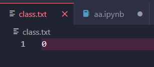

Есть объекты, разметку у которых лучше удалить. Пример на фотографиии ниже, в красном прямоугольнике: из-за того что лицо практически полностью закрыто и его, по сути, не видно, подобные объекты лучше удалять. Некорректные данные могут плохо сказаться на качестве модели

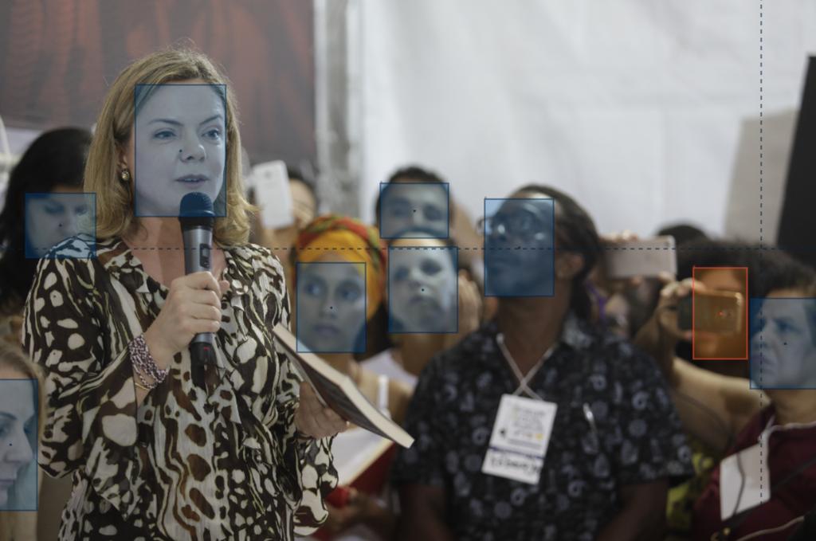

Так же я решила удалять объекты, который очень размытые и находятся далеко на заднем плане фотографии. Пример на фотографии ниже в красном прямоугольнике:

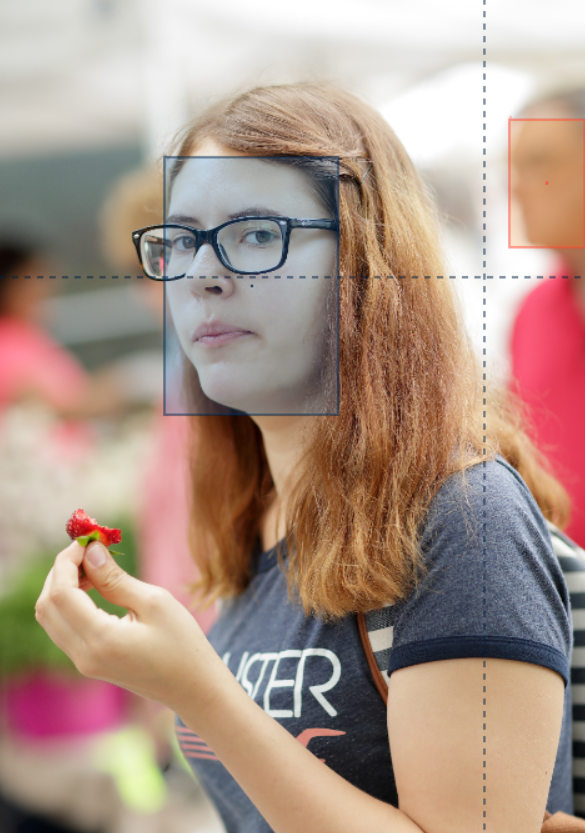

### Разархивация переразмеченных данных

Так как новая переразметка скачивается архивом, её надо извлечь. Извлечённые данные будут в папке "data_raz"

```python
# путь к архиву
arch3 = 'bboxes_yolo.zip'

with zipfile.ZipFile(arch3, 'r') as zip_file3: # открытие архива
    zip_file3.extractall('data_raz') # данные извлекаются в data_raz
```

- В папке "data_raz" хранятся только .txt файлы с новой разметкой

Теперь нужно сделать словарь с переразмеченными данными, как было сделано с исходными

```python
# путь к папке с переразметкой
fol_path_new = 'data_raz'

class_vals_new = defaultdict(int)

for filename in os.listdir(fol_path_new):
    file_path = os.path.join(fol_path_new, filename)

    with open(file_path, 'r') as f:
        for line in f:
            line = line.strip()
            if line:
                first_space = line.find(' ')
                first_part = line[:first_space] if first_space != -1 else line

                if first_part.isdigit():
                    class_vals_new[int(first_part)] += 1

new_s_class_vals = OrderedDict(sorted(class_vals_new.items()))
print(new_s_class_vals)
```

```
OrderedDict([(0, 1331)])
```

#### Сравнение кол-ва данных до и после переразметки

Исходная разметка:

> OrderedDict([(0, 1424)])

Новая разметка:

> OrderedDict([(0, 1331)])
- Новые лица обнаружены не были
- Удалены некорреткно размеченные объекты (меньше 40-50% от лица на кадре; очень размытые лица)

В итоге количество размеченных объектов уменьшилось на 93

## Анализ набора данных для идентификации

- Выведем, у скольких людей сколько фотографий в данных присутствует

```python
df2
```

|  | name | images |
| --- | --- | --- |
| 0 | AJ_Cook | 1 |
| 1 | AJ_Lamas | 1 |
| 2 | Aaron_Eckhart | 1 |
| 3 | Aaron_Guiel | 1 |
| 4 | Aaron_Patterson | 1 |
| ... | ... | ... |
| 5744 | Zorica_Radovic | 1 |
| 5745 | Zulfiqar_Ahmed | 1 |
| 5746 | Zumrati_Juma | 1 |
| 5747 | Zurab_Tsereteli | 1 |
| 5748 | Zydrunas_Ilgauskas | 1 |

5749 rows × 2 columns

Выведем уникальные значения по колонке "images":

```python
df2['images'].unique()
```

```
array([  1,   4,   2,  19,   3,  12,   5,   8,   7,   6,  39,  35,  21,
        36,  15,  20,  11,  13,  77,  42,  24,  29,   9,  17,  10,  14,
       236,  31, 121,  18,  22, 530, 109,  44,  26,  30,  16,  71,  28,
        52,  55,  53,  23,  60,  32,  41,  48,  33,  37,  27,  25, 144,
        49])
```

```python
df2['images'].value_counts()
```

```
images
1      4069
2       779
3       291
4       187
5       112
6        55
7        39
8        33
9        26
11       16
10       15
13       11
15       11
12       10
```

[output cut: 40 more lines]

Выше выведены две колонки: левая - уникальные значения из "images", правая - количество этих значений по всей этой колонке

Больше всего людей, у которых в данных по одной фотке - таких 4069

Визуализируем это:

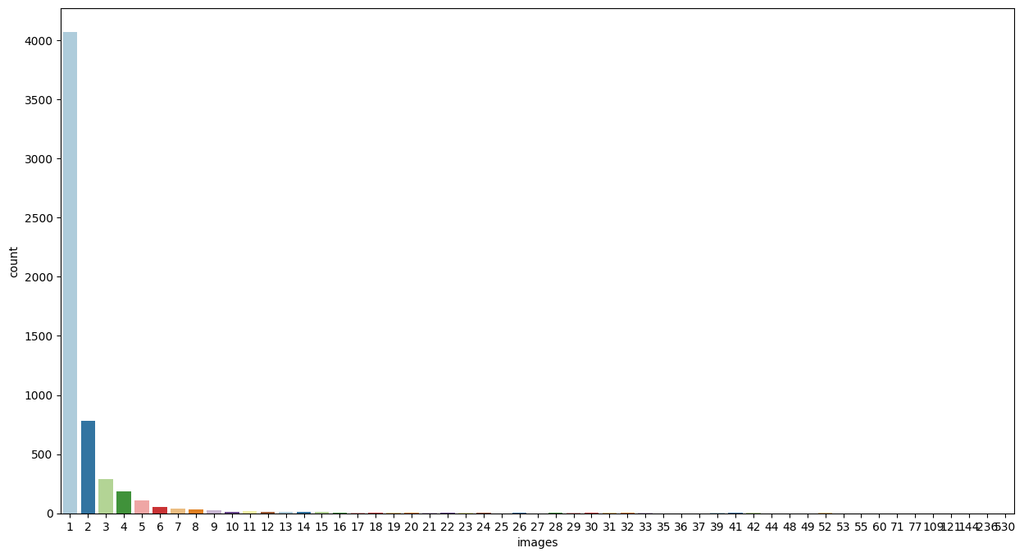

```python
plt.figure(figsize=(15, 8))
sns.countplot(df2, x = 'images', palette = 'Paired')
plt.show()
```

- Очень сильно бросается в глаза, что папок, в которых по одной фотографии, намного больше чем остальных.

Для корректной идентификации одной фотографии может быть недостаточно, тем более с учётом того, что в дальнейшем данные необходимо будет разделить на обучающую, валидационную и тестовую выборки.

Данных с одной фотографией очень много -> дополнить их для последующего разделения на выборки будет проблематично, поэтому их можно удалить.

Так как данные поделить будет необходимо на три выборки, надо взять минимальное количество фотографий на каждого человека равное трём, но по одной фотографии на каждую выборку тоже может быть недостаточно, поэтому я решила взять от 9-ти фотографий минимум, чтобы в каждой выборке было хотя бы по три фото.

Из-за того, что далеко не все значения из колонки "images" нацело делятся на три, а так же из-за того, что будет не очень хорошо, если в валидационной выборке будет сильный дисбаланс по количеству фото на человека, я разделю данные следующим образом:

- По три рандомные фотографии в тестовую и валидационную выборки
- Остальные фотографии будут в обучающей выборке

Следуя из всего, что написано выше, я удаляю все строки, где значение в колонке "images" меньше 9-ти:

```python
# в новой переменной сохраняем датафрейм со значениями 9 и больше по колонке "images"
df2_d = df2[df2['images'] >= 9]
# выводим размер
df2_d.shape
```

```
(184, 2)
```

Осталось 184 строки -> 184 человека для идентификации

Перед тем как разделить данные на выборки, нужно ещё немного проанализовать данные, так как могут быть ещё данные, которые лучше будет удалить

Выведем топ 10 имён по количеству фотографий:

```python
df2d_top10 = df2_d.nlargest(10, 'images')
df2d_top10
```

|  | name | images |
| --- | --- | --- |
| 1871 | George_W_Bush | 530 |
| 1047 | Colin_Powell | 236 |
| 5458 | Tony_Blair | 144 |
| 1404 | Donald_Rumsfeld | 121 |
| 1892 | Gerhard_Schroeder | 109 |
| 373 | Ariel_Sharon | 77 |
| 2175 | Hugo_Chavez | 71 |
| 2941 | Junichiro_Koizumi | 60 |
| 2468 | Jean_Chretien | 55 |
| 2682 | John_Ashcroft | 53 |

530 и 236 объектов, по сравнению с остальным количеством фото на человека, это очень много и чтобы модель не переобучалась на конкретных личностях, надо сократить кол-во фотографий

- так же сокращение данных сможет поспособствовать более высокой скороти обучения

Визуализируем данные в "images"

(по датафрейму df2_d)

```
array([[<Axes: title={'center': 'images'}>]], dtype=object)
```

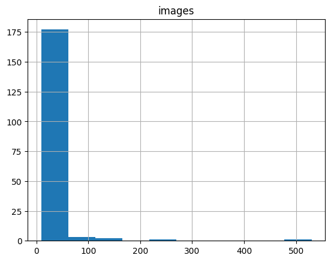

```python
df2_d.hist() # строим гистограмму
```

На графике показано распределение значений количества фотографий на одного человека. Основная часть значений по колонке лежит на отрезке от 0 до 100 -> среди данных по большей части до 100 фотографий на человека.

Больше всего значений находится около 50-ти штук (*до 50-ти).

- Так же по колонке "images" можно вывести генеральную описательную статистику с помощью метода describe():

```python
df2_d.describe()
```

|  | images |
| --- | --- |
| count | 184.000000 |
| mean | 24.771739 |
| std | 44.552322 |
| min | 9.000000 |
| 25% | 11.000000 |
| 50% | 15.000000 |
| 75% | 23.000000 |
| max | 530.000000 |

Среднее значение в колонке равно ~24,8. Чтобы не так сильно обрезать данные из папок, где значений в несколько раз больше, чем это среднее, а таких достаточно, я из каждой папки, где более 50-ти фотографий, буду оставляять рандомные 50 на обучающую выборку (и по три на валидационную и тестовую)

### Подготовка данных для задачи детекции лиц к обучению модели

- Переразметка фотографий сделана, но перед обучением необходимо разделить эти данные на тренировочную, тестовую и валидационную выборки

Нужно, чтобы структура данных в конечном формате была такой:

```
-- rec_data     # папка с разделёнными данным

     -- test  # тестовая выборка

          -- images

          -- labels

     -- train  # обучающая выборка

          -- images

          -- labels

     -- valid  # валидационная выборка

          -- images

          -- labels
```

```python
import shutil
import numpy as np
from sklearn.model_selection import train_test_split
```

```python
# путь к фото
img_dir = r'archive2\Custom_Data\images\train'
# путь к разметке (переделанной)
labels_dir = r'data_raz'

# пути к папкам train, test, valid
train_img_f = r'rec_data\train\images'
train_lab_f = r'rec_data\train\labels'
test_img_f = r'rec_data\test\images'
test_lab_f = r'rec_data\test\labels'
valid_img_f = r'rec_data\valid\images'
valid_lab_f = r'rec_data\valid\labels'

# в списке сохраняем
# названия всех файлов с фотографими без расширения
img_files = [f.split('.')[0] for f in os.listdir(img_dir) if f.endswith('.png')]
print(img_files) # проверка того, что добавилось в img_files
# разделение на обучающую и тестовую выборки
# сначала берём 15% на тест
train_files, test_files = train_test_split(img_files, test_size = 0.15, random_state = 42)
# от обучающей выборки берём 15% на валидационную
train_files, val_files = train_test_split(train_files, test_size = 0.15, random_state = 42)

# функция для копирования файлов в папки
def copy_files(files, source_images_dir, source_labels_dir, target_images_dir, target_labels_dir):
    for f in files:
        # копируем файл с фото
        shutil.copy(os.path.join(source_images_dir, f'{f}.png'), os.path.join(target_images_dir, f'{f}.png'))
        shutil.copy(os.path.join(source_labels_dir, f'{f}.txt'), os.path.join(target_labels_dir, f'{f}.txt'))

# вызываем функцию для копирования
copy_files(train_files, img_dir, labels_dir, train_img_f, train_lab_f)
copy_files(test_files, img_dir, labels_dir, test_img_f, test_lab_f)
copy_files(val_files, img_dir, labels_dir, valid_img_f, valid_lab_f)
```

****тут должен был быть выведен спискок img_files `py print(img_files)`, но чтото пошло не так и я случайно удалила вывод ячейки, а перезапустить ячейку не могу так как результат её работы выполнен...... но короче всё сделалось разделилось всё как надо

Выборки выделены, но надо посмотреть точное количество данных в каждой выборке

```python
from pathlib import Path

dir_train_img = Path(r'rec_data\train\images') # путь к папке train с фото
dir_train_lb = Path(r'rec_data\train\labels') # путь к папке train с разметкой
dir_test_img = Path(r'rec_data\test\images') # путь к папке test с фото
dir_test_lb = Path(r'rec_data\test\labels') # путь к папке test с разметкой
dir_valid_img = Path(r'rec_data\valid\images') # путь к папке valid с фото
dir_valid_lb = Path(r'rec_data\valid\labels') # путь к папке valid с разметкой

# считаем количество файлов в каждой из папок выше
n_f_train_img = sum(1 for i in dir_train_img.iterdir() if i.is_file())
n_f_train_lab = sum(1 for i in dir_train_lb.iterdir() if i.is_file())
n_f_test_img = sum(1 for i in dir_test_img.iterdir() if i.is_file())
n_f_test_lab = sum(1 for i in dir_test_lb.iterdir() if i.is_file())
n_f_valid_img = sum(1 for i in dir_valid_img.iterdir() if i.is_file())
n_f_valid_lab = sum(1 for i in dir_valid_lb.iterdir() if i.is_file())

print(f'''
Количество фотографий в обучающей выборке: {n_f_train_img}
Количество файлов с разметкой в обучающей выборке: {n_f_train_lab}
Количество фотографий в тестовой выборке: {n_f_test_img}
Количество файлов с разметкой в тестовой выборке: {n_f_test_lab}
Количество фотографий в валидационной выборке: {n_f_valid_img}
Количество файлов с разметкой в валидационой выборке: {n_f_valid_lab}
''')
```

```
Количество фотографий в обучающей выборке: 833
Количество файлов с разметкой в обучающей выборке: 833
Количество фотографий в тестовой выборке: 174
Количество файлов с разметкой в тестовой выборке: 174
Количество фотографий в валидационной выборке: 147
Количество файлов с разметкой в валидационой выборке: 147
```

Кол-во данных в папках images и labels по каждой выборке совпадает, -> данные были разделены корректно.

В итоге получилось следующее разделение:

> -- Обучающая выборка: 833 объекта

> -- Тестовая выборка: 174 объекта

> -- Валидационная выборка: 147 объектов
- Для модели нужно сделать файл в формате .yaml, в котором будет информация о том, где расположены необходимые данные для обучения

Для этого я создала файл "data_det.yaml". Его структура следующая:

```
train: ../rec_data/train/images # путь к фотографиям из обучающей выборки
val: ../rec_data/valid/images   # путь к фотографиям из валидационной выборки
test: ../rec_data/test/images   # путь к фотографиям из тестовой выборки

nc: 1  # количество классов, которые нужно детектировать
names: ['face'] # названия детектируемых классов (в рамках этой задачи класс один)
```

### Подготовка данных для задачи идентификации лиц к обучению модели

```python
main_dir = r'lfw-deepfunneled' # путь к папке с папками по именам
# пути к папкам train, test, valid
train_id_dir = r'id_data\train'
valid_id_dir = r'id_data\valid'
test_id_dir = r'id_data\test'


# в список заносим все значения, которые есть в
# первой колонке в df2_d (названия папок с именами)
folders = df2_d.iloc[:, 0].tolist()

def distribution_ph(person_folder, src_path, train_path, test_path, valid_path):
    photos = os.listdir(src_path) # список с названиями всех файлов в папке
    photos = sample(photos,len(photos)) # перемешивание списка, чтобы фото были в рандом. порядке

    # берём по 3 фото на test и valid
    test_photos = photos[:3]
    valid_photos = photos[3:6]

    # остальное в train
    train_photos = photos[6:]
    # если элементов осталось больше, чем 50, то в train идут рандомные 50 фотографий
    if len(train_photos) > 50:
        train_photos = sample(train_photos, 50)

    for dest, photo_list in [(test_path, test_photos), (valid_path, valid_photos), (train_path, train_photos)]:
        os.makedirs(dest, exist_ok=True)
        for photo in photo_list:
            shutil.copy(os.path.join(src_path, photo), os.path.join(dest, photo)) # копируем нужные фотографии в папки


# копируем и распределяем фотографии
for folder in folders:
    person_src_path = os.path.join(main_dir, folder)
    print(person_src_path)
    if not os.path.exists(person_src_path):
        continue
    # пути к папкам по людям для выборок
    train_person_path = os.path.join(train_id_dir, folder)
    test_person_path = os.path.join(test_id_dir, folder)
    valid_person_path = os.path.join(valid_id_dir, folder)

# вызываем функцию распределения
    distribution_ph(folder, person_src_path, train_person_path, test_person_path, valid_person_path)

print('Данные разбиты на обучающую, валидационную и тестовую выборки')
```

[output not shown]

[output cut: 130 more lines]

```
lfw-deepfunneled\Tommy_Franks
lfw-deepfunneled\Tommy_Thompson
lfw-deepfunneled\Tony_Blair
lfw-deepfunneled\Trent_Lott
lfw-deepfunneled\Tung_Chee-hwa
lfw-deepfunneled\Vaclav_Havel
lfw-deepfunneled\Venus_Williams
lfw-deepfunneled\Vicente_Fox
lfw-deepfunneled\Vladimir_Putin
lfw-deepfunneled\Walter_Mondale
lfw-deepfunneled\Wen_Jiabao
lfw-deepfunneled\Winona_Ryder
lfw-deepfunneled\Yoriko_Kawaguchi
lfw-deepfunneled\Zhu_Rongji
Данные разбиты на обучающую, валидационную и тестовую выборки
```

Проверяем, чтобы кол-во папок совпадало:

```python
dir_train_id = Path(r'id_data\train') # путь к папке train с фото
dir_test_id = Path(r'id_data\test') # путь к папке test с фото
dir_valid_id = Path(r'id_data\valid') # путь к папке valid с фото

# считаем количество файлов в каждой из папок выше
n_f_train_id = sum(1 for i in dir_train_id.iterdir())
n_f_test_id = sum(1 for i in dir_test_id.iterdir())
n_f_valid_id = sum(1 for i in dir_valid_id.iterdir())

print(f'''
Количество папок в обучающей выборке: {n_f_train_id}
Количество папок в тестовой выборке: {n_f_test_id}
Количество папок в валидационной выборке: {n_f_valid_id}
''')
```

```
Количество папок в обучающей выборке: 184
Количество папок в тестовой выборке: 184
Количество папок в валидационной выборке: 184
```

-> В каждой из выборок представлены фотографии 184-ёх людей

Для каждой из папок train, tset, valid сделаем датафреймы для анализа, в которых будут храниться названия папок и количество фотографий в них

```python
id_folders = 'id_data'  # путь к папке с папками train, test, valid

# функция для создания дф
def create_df(id_folder):
    data = []
    if os.path.exists(id_folder):
        folders_in_fol = os.listdir(id_folder)
        for f in folders_in_fol:
            f_path = os.path.join(id_folder, f) # полный путь к папке с именем
            if os.path.isdir(f_path): # проверка на то что f_path - папка
                photos = os.listdir(f_path) # список фоток

                data.append({'Name': f, 'Photo_count': len(photos)})
    return pd.DataFrame(data)


train_id_df = create_df(r'id_data\train')
valid_id_df = create_df(r'id_data\valid')
test_id_df = create_df(r'id_data\test')
```

```python
print(train_id_df) # обучающая выборка
```

```
                 Name  Photo_count
0        Abdullah_Gul           13
1        Adrien_Brody            6
2    Alejandro_Toledo           33
3        Alvaro_Uribe           29
4     Amelie_Mauresmo           15
..                ...          ...
179    Walter_Mondale            4
180        Wen_Jiabao            7
181      Winona_Ryder           18
182  Yoriko_Kawaguchi            8
183        Zhu_Rongji            3

[184 rows x 2 columns]
```

```python
print(valid_id_df) # валидационная выборка
```

```
                 Name  Photo_count
0        Abdullah_Gul            3
1        Adrien_Brody            3
2    Alejandro_Toledo            3
3        Alvaro_Uribe            3
4     Amelie_Mauresmo            3
..                ...          ...
179    Walter_Mondale            3
180        Wen_Jiabao            3
181      Winona_Ryder            3
182  Yoriko_Kawaguchi            3
183        Zhu_Rongji            3

[184 rows x 2 columns]
```

```python
print(test_id_df) # тестовая выборка
```

```
                 Name  Photo_count
0        Abdullah_Gul            3
1        Adrien_Brody            3
2    Alejandro_Toledo            3
3        Alvaro_Uribe            3
4     Amelie_Mauresmo            3
..                ...          ...
179    Walter_Mondale            3
180        Wen_Jiabao            3
181      Winona_Ryder            3
182  Yoriko_Kawaguchi            3
183        Zhu_Rongji            3

[184 rows x 2 columns]
```

Проверим, что в valid и test по 3 фотографии:

```python
print(f'''
Уникальные значения в колонке Photo_count в valid: {valid_id_df['Photo_count'].unique()}
Уникальные значения в колонке Photo_count в test: {test_id_df['Photo_count'].unique()}
''')
```

```
Уникальные значения в колонке Photo_count в valid: [3]
Уникальные значения в колонке Photo_count в test: [3]
```

-> в valid и test по 3 фотографии

Визуализируем распределение значений в обучаюзей выборке по кличеству фотографий в папке:

```
array([[<Axes: title={'center': 'Photo_count'}>]], dtype=object)
```

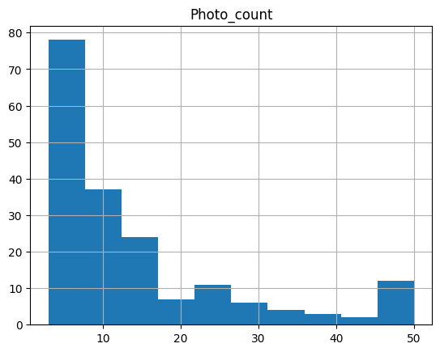

```python
train_id_df.hist() # строим гистограмму
```

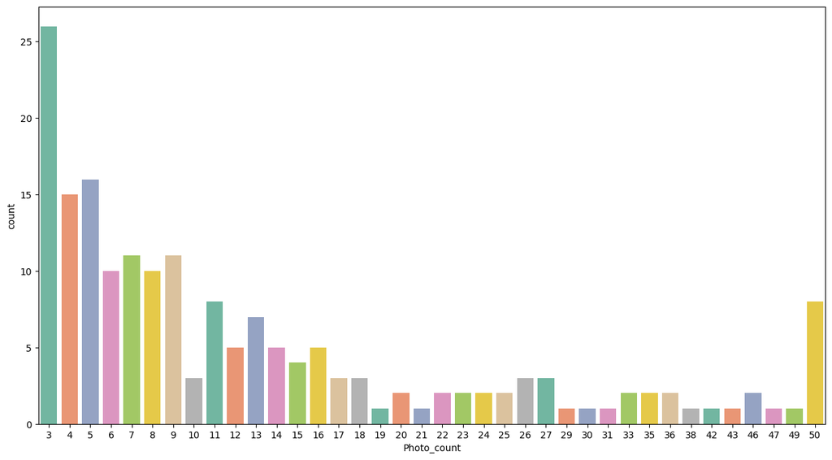

```python
plt.figure(figsize=(15, 8))
sns.countplot(train_id_df, x = 'Photo_count', palette = 'Set2')
plt.show()
```

На графике выше по оси Х находится кол-во фотографий в папке, в по оси Y - кол-во папок, у которых столько фотографий

Так же можно вывести общее количество всех фотографий в обучающей выборке:

```python
total_train = train_id_df['Photo_count'].sum()
print(f'Общее количество фотографий в train: {total_train}')
```

```
Общее количество фотографий в train: 2554
```

В итоге остались данные о 184-ёх человек, общее количество фотографий для обучения - 2554. Этого будет достаточно для обучения модели идентификации лиц

# Отчёт

- Данные были просмотрены и проанализированы
- Сделана переразметка данных для детекции
- Данные подготовлены к обучению; разбиты на обучающую, валидационную и тестовую выборки